# Module4L2

Neha Parulekar

February 16, 2016

# Additional packages needed

- If necessary install `ggplot2, cluster and amap` packages.

`install.packages("ggplot2");`  
`install.packages("cluster");`  
`install.packages("amap");`  
`install.packages("useful");`

```r
require(ggplot2)
require(cluster)
require(amap)
require(useful)
```

- Go to the [UC Irvine Machine Learning Repository](https://archive.ics.uci.edu/ml/) and find a dataset for clustering. Every student MUST use a different dataset so you MUST get approved for which you can going to use.

### Loading the dataset

```r
# set the working directory
setwd("C:/Users/Neha/Desktop")

# load the file
ProtienExpressionData <- read.csv("Data_Cortex_Nuclear.csv")

# Checking the data
head(ProtienExpressionData)
```

```
##   MouseID  DYRK1A_N   ITSN1_N    BDNF_N    NR1_N   NR2A_N    pAKT_N
## 1   309_1 0.5036439 0.7471932 0.4301753 2.816329 5.990152 0.2188300
## 2   309_2 0.5146171 0.6890635 0.4117703 2.789514 5.685038 0.2116362
## 3   309_3 0.5091831 0.7302468 0.4183088 2.687201 5.622059 0.2090109
## 4   309_4 0.4421067 0.6170762 0.3586263 2.466947 4.979503 0.2228858
## 5   309_5 0.4349402 0.6174298 0.3588022 2.365785 4.718679 0.2131059
## 6   309_6 0.4475064 0.6281758 0.3673881 2.385939 4.807635 0.2185778
##     pBRAF_N pCAMKII_N   pCREB_N   pELK_N    pERK_N    pJNK_N    PKCA_N
## 1 0.1775655  2.373744 0.2322238 1.750936 0.6879062 0.3063817 0.4026984
## 2 0.1728170  2.292150 0.2269721 1.596377 0.6950062 0.2990511 0.3859868
## 3 0.1757222  2.283337 0.2302468 1.561316 0.6773484 0.2912761 0.3810025
## 4 0.1764626  2.152301 0.2070042 1.595086 0.5832768 0.2967287 0.3770870
## 5 0.1736270  2.134014 0.1921579 1.504230 0.5509601 0.2869612 0.3635021
## 6 0.1762334  2.141282 0.1951875 1.442398 0.5663396 0.2898239 0.3638930
##      pMEK_N    pNR1_N   pNR2A_N  pNR2B_N pPKCAB_N    pRSK_N     AKT_N
```

[output cut: 69 more lines]

```r
# Removing the NA columns and columns without protien expression (last four cols)from the data

RemoveColms <- c("MouseID","Genotype","Treatment","Behavior","class")
ModifiedProtienExpressionData <- ProtienExpressionData[, !(names(ProtienExpressionData) %in% RemoveColms)]

ModifiedProtienExpressionData <- ModifiedProtienExpressionData[complete.cases(ModifiedProtienExpressionData),]

#ModifiedProtienExpressionData
```

- Cluster some of your data using k-means, PAM and hierarchical clustering. Answer the following questions:

** *Determining the k from Kmeans** First determine the number of clusters then apply hartigans rule to get the K

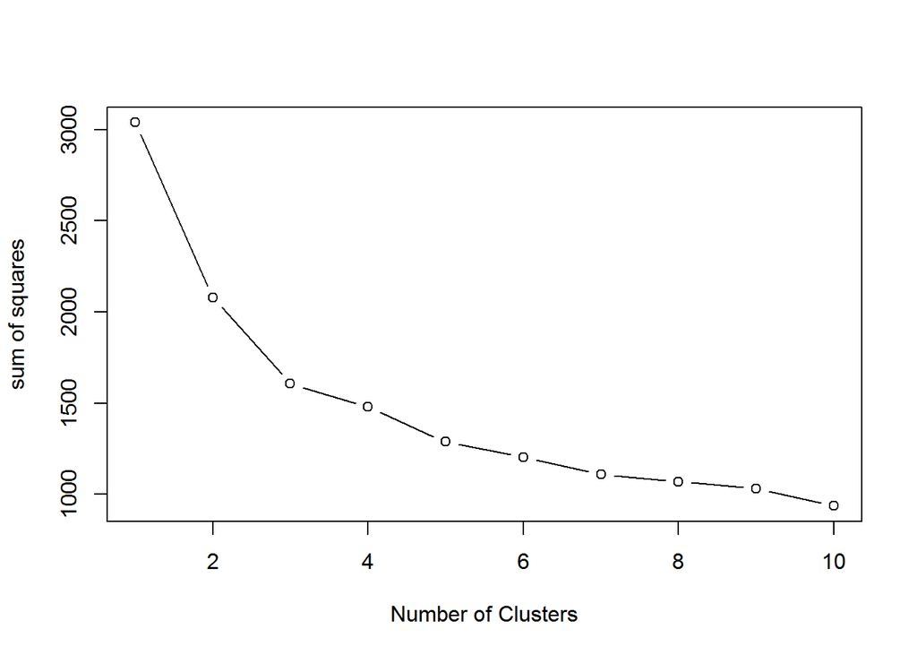

```r
# Determining the number of clusters
sos <- (nrow(ModifiedProtienExpressionData)-1)*sum(apply(ModifiedProtienExpressionData,2,var))
for(i in 2:10) sos[i] <- sum(kmeans(ModifiedProtienExpressionData, centers = i)$withinss)
plot(1:10, sos, type = "b", xlab = "Number of Clusters", ylab = "sum of squares")
```

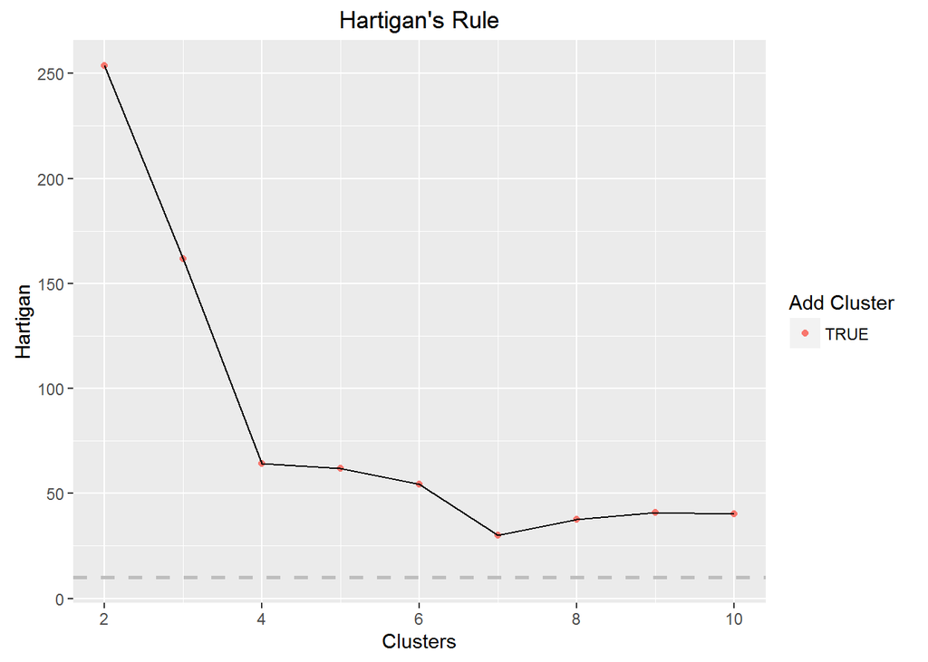

```r
# hartigans rule
best <- FitKMeans(ModifiedProtienExpressionData, max.clusters = 10, seed = 111)
PlotHartigan(best)
```

```r
# Taking K value as 5
k <- 5
ProtienData.5.clust <- kmeans(ModifiedProtienExpressionData, k)
ProtienData.5.clust
```

```
## K-means clustering with 5 clusters of sizes 85, 156, 86, 116, 109
##
## Cluster means:
##    DYRK1A_N   ITSN1_N    BDNF_N    NR1_N   NR2A_N    pAKT_N   pBRAF_N
## 1 0.4687297 0.7073690 0.3486172 2.539773 4.540074 0.2573975 0.1890816
## 2 0.4286131 0.6394449 0.3088677 2.275477 3.694364 0.2144681 0.1692128
## 3 0.5000793 0.7604731 0.3849536 2.814014 4.997050 0.2184330 0.1797060
## 4 0.3575136 0.5080725 0.2583661 1.847593 2.727615 0.1965071 0.1576442
## 5 0.3488679 0.5480937 0.3026220 2.199524 3.491534 0.2478431 0.1892473
##   pCAMKII_N   pCREB_N   pELK_N    pERK_N    pJNK_N    PKCA_N    pMEK_N
## 1  5.835489 0.2359690 1.478614 0.5521874 0.3539322 0.3711800 0.3067096
## 2  2.798917 0.2039048 1.371361 0.5441249 0.2939760 0.3141824 0.2544818
## 3  3.241073 0.2378086 1.585516 0.6988412 0.3265057 0.3568880 0.2774458
## 4  2.376330 0.1700941 1.214749 0.4526256 0.2492562 0.2562128 0.2224347
## 5  4.696940 0.2103770 1.272368 0.4277890 0.3360777 0.3169156 0.2846235
```

[output cut: 146 more lines]